# Trabalho ASN Regressão Linear

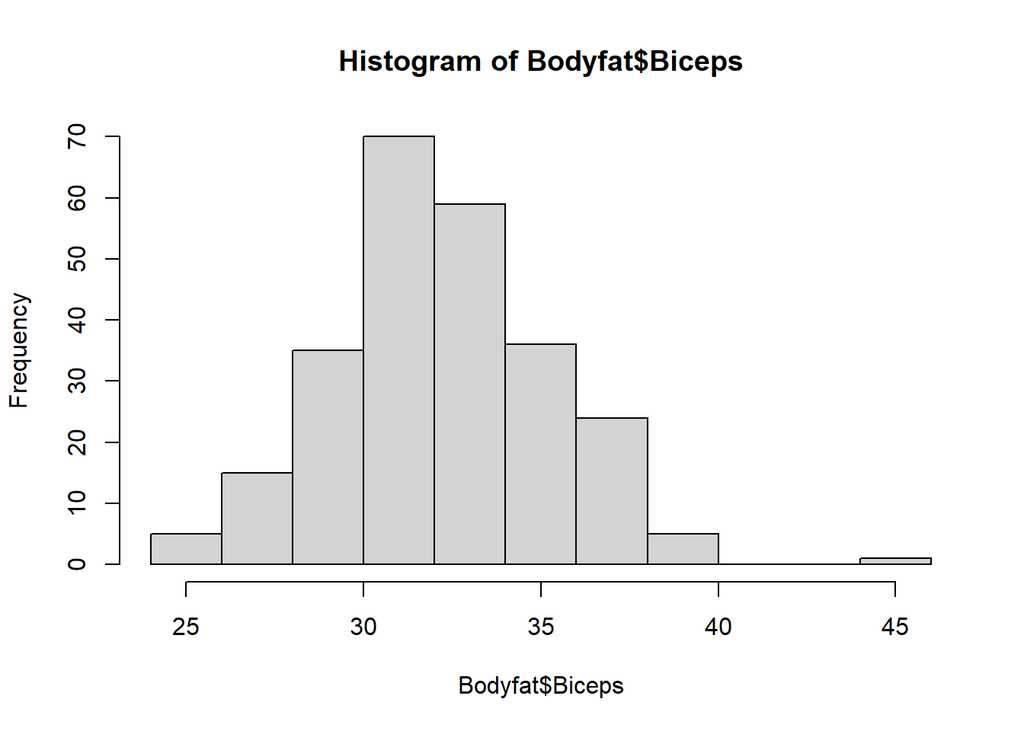

```r
hist(Bodyfat$Biceps)
```

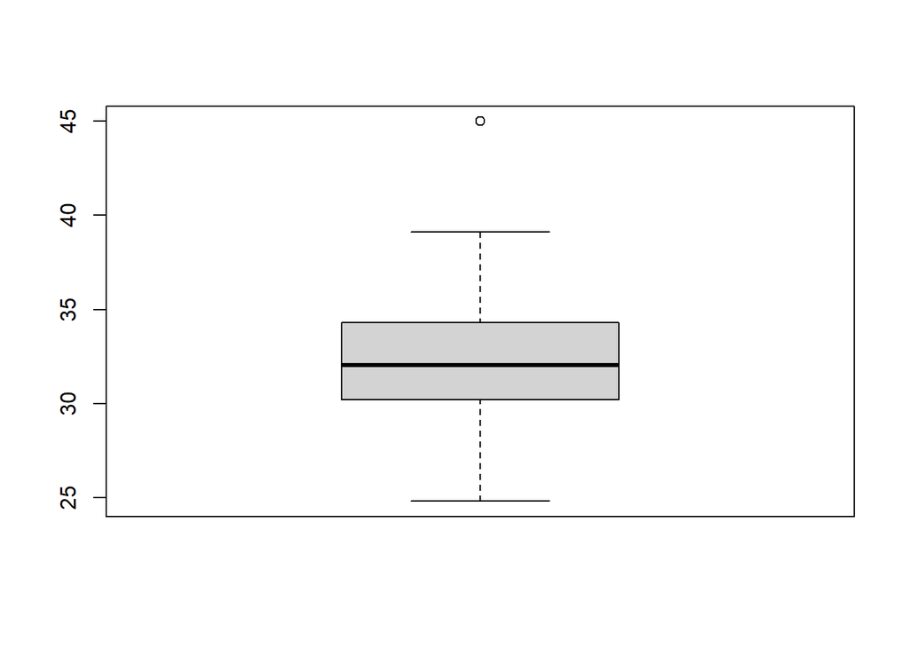

```r
boxplot(Bodyfat$Biceps)
```

```r
#Analisando os outliers
Bodyfat_Biceps= Bodyfat[order(Bodyfat$Biceps),]
tail(Bodyfat_Biceps ,4)
```

```
## # A tibble: 4 × 14
##   bodyfat   Age Weight Height  Neck Chest Abdomen   Hip Thigh  Knee Ankle Biceps
##     <dbl> <dbl>  <dbl>  <dbl> <dbl> <dbl>   <dbl> <dbl> <dbl> <dbl> <dbl>  <dbl>
## 1     6.3    49   69.3   1.84  35.1  93.3    79.6  91.6  52.6  37.6  22.6   38.5
## 2    19.6    26  110.    1.86  41.8 108.    103.  114.   72.9  43.5  25.1   38.5
## 3    16.9    39  106.    1.86  42.8 110.    104.  110.   69.5  43.1  25.8   39.1
## 4    35.2    46  165.    1.81  51.2 136.    148.  148.   87.3  49.1  29.6   45
## # … with 2 more variables: Forearm <dbl>, Wrist <dbl>
```

```r
# Carrega pacote
#library(nortest)

# Realiza o teste
testeShapiro <- shapiro.test(Bodyfat$Biceps)

# Exibe teste
testeShapiro
```

```
##
##  Shapiro-Wilk normality test
##
## data:  Bodyfat$Biceps
## W = 0.98831, p-value = 0.0402
```

```r
filter(Bodyfat, is.na(Biceps))
```

```
## # A tibble: 0 × 14
## # … with 14 variables: bodyfat <dbl>, Age <dbl>, Weight <dbl>, Height <dbl>,
## #   Neck <dbl>, Chest <dbl>, Abdomen <dbl>, Hip <dbl>, Thigh <dbl>, Knee <dbl>,
## #   Ankle <dbl>, Biceps <dbl>, Forearm <dbl>, Wrist <dbl>
```

**Forearm(AnteBraço):**

Analisando os dados estatisticos.

```r
summary(Bodyfat$Forearm)
```

```
##    Min. 1st Qu.  Median    Mean 3rd Qu.    Max.
##   21.00   27.30   28.70   28.68   30.00   34.90
```

```r
sd(Bodyfat$Forearm)
```

```
## [1] 2.012135
```

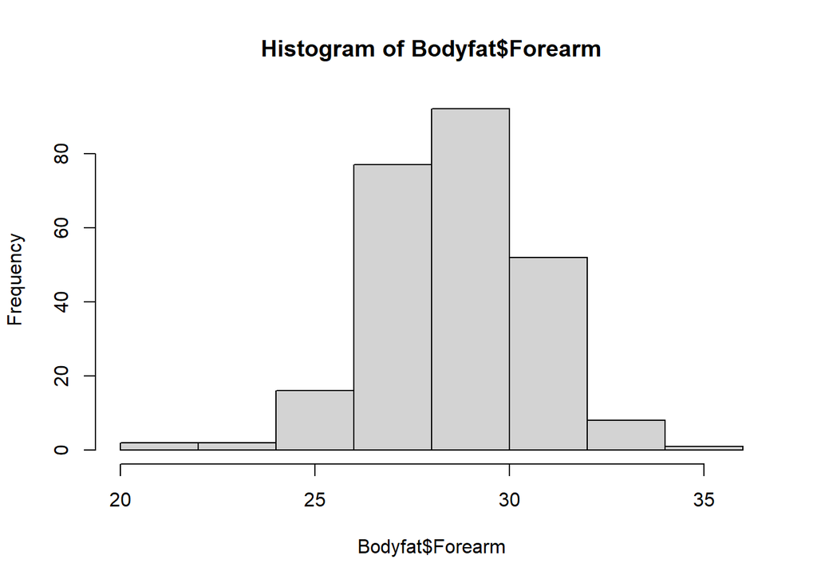

```r
hist(Bodyfat$Forearm)
```

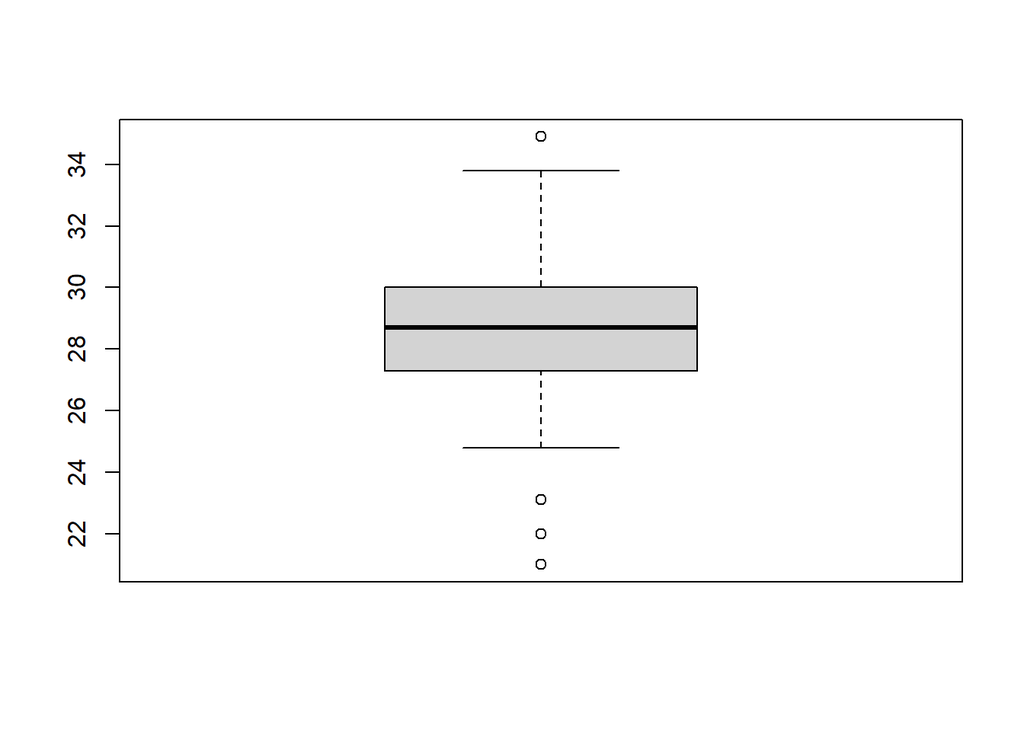

```r
boxplot(Bodyfat$Forearm)
```

```r
#Analisando os outliers
Bodyfat_Forearm= Bodyfat[order(Bodyfat$Forearm),]
tail(Bodyfat_Forearm ,4)
```

```
## # A tibble: 4 × 14
##   bodyfat   Age Weight Height  Neck Chest Abdomen   Hip Thigh  Knee Ankle Biceps
##     <dbl> <dbl>  <dbl>  <dbl> <dbl> <dbl>   <dbl> <dbl> <dbl> <dbl> <dbl>  <dbl>
## 1    20.3    35  102.    1.81  43.9 108.    100.  107.   63.3  41.7  24.6   37.2
## 2    19.2    35   98.4   1.84  40.5 108.     95.1 104.   64.8  41.3  25.6   36.4
## 3    19.6    26  110.    1.86  41.8 108.    103.  114.   72.9  43.5  25.1   38.5
## 4    12.5    30   61.9   1.72  35.9  88.7    76.6  89.8  50.1  34.8  21.8   27
## # … with 2 more variables: Forearm <dbl>, Wrist <dbl>
```

```r
# Carrega pacote
#library(nortest)

# Realiza o teste
testeShapiro <- shapiro.test(Bodyfat$Forearm)

# Exibe teste
testeShapiro
```

```
##
##  Shapiro-Wilk normality test
##
## data:  Bodyfat$Forearm
## W = 0.9877, p-value = 0.03095
```

```r
filter(Bodyfat, is.na(Forearm))
```

```
## # A tibble: 0 × 14
## # … with 14 variables: bodyfat <dbl>, Age <dbl>, Weight <dbl>, Height <dbl>,
## #   Neck <dbl>, Chest <dbl>, Abdomen <dbl>, Hip <dbl>, Thigh <dbl>, Knee <dbl>,
## #   Ankle <dbl>, Biceps <dbl>, Forearm <dbl>, Wrist <dbl>
```

**Wrist(Pulso):**

Analisando os dados estatisticos.

```r
summary(Bodyfat$Wrist)
```

```
##    Min. 1st Qu.  Median    Mean 3rd Qu.    Max.
##   15.80   17.60   18.30   18.24   18.80   21.40
```

```r
sd(Bodyfat$Wrist)
```

```
## [1] 0.9308113
```

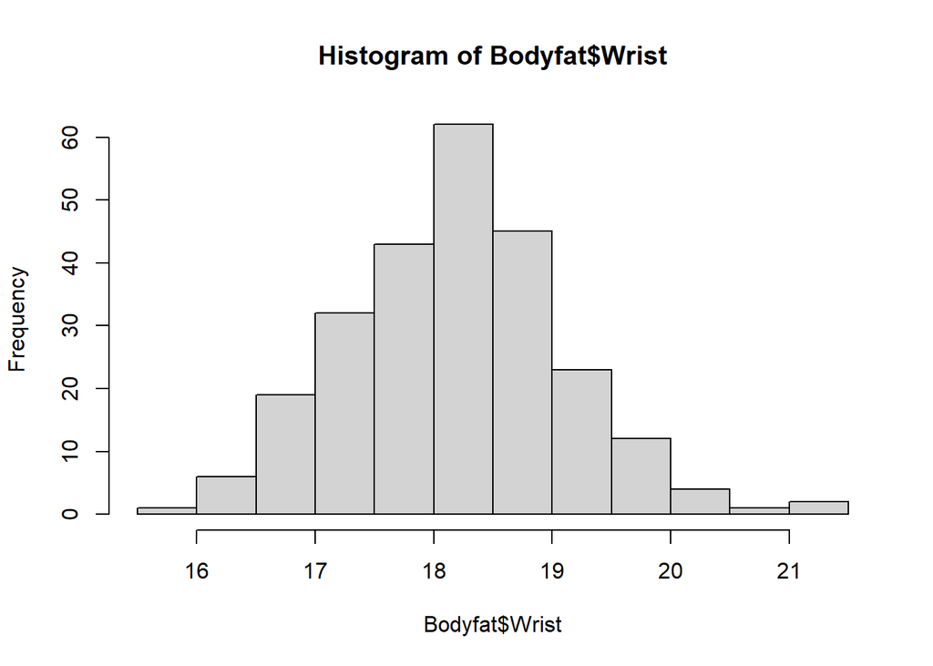

```r
hist(Bodyfat$Wrist)
```

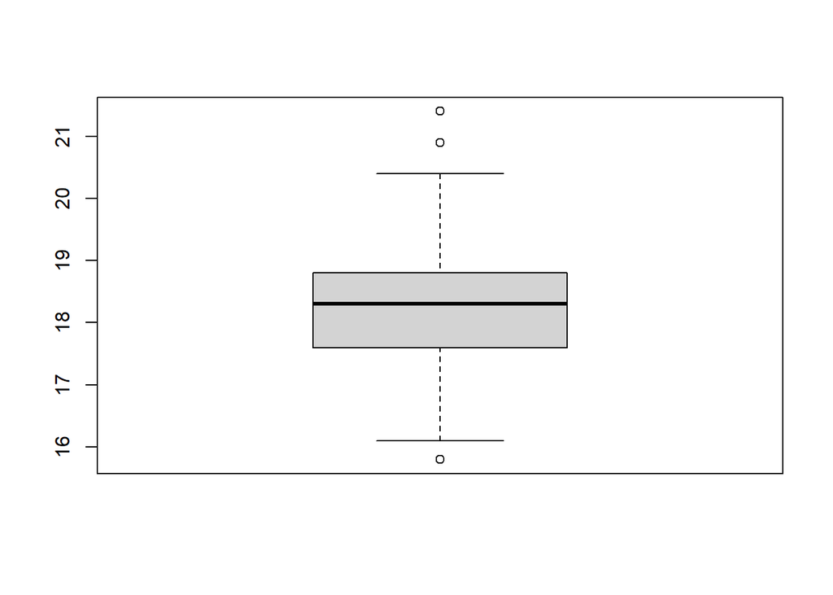

```r
boxplot(Bodyfat$Wrist)
```

```r
#Analisando os outliers
Bodyfat_Wrist= Bodyfat[order(Bodyfat$Wrist),]
tail(Bodyfat_Wrist ,4)
```

```
## # A tibble: 4 × 14
##   bodyfat   Age Weight Height  Neck Chest Abdomen   Hip Thigh  Knee Ankle Biceps
##     <dbl> <dbl>  <dbl>  <dbl> <dbl> <dbl>   <dbl> <dbl> <dbl> <dbl> <dbl>  <dbl>
## 1    17.4    53  102.    1.94  41.1  113.    99.2  108.  61.7  42.3  23.2   32.9
## 2    31.9    74   94.1   1.75  40.8  112.   108.   107.  59.3  42.2  24.6   33.7
## 3    35.2    46  165.    1.81  51.2  136.   148.   148.  87.3  49.1  29.6   45
## 4    34.5    45  119.    1.72  43.2  128.   126.   126.  72.5  39.6  26.6   36.4
## # … with 2 more variables: Forearm <dbl>, Wrist <dbl>
```

```r
# Carrega pacote
#library(nortest)

# Realiza o teste
testeShapiro <- shapiro.test(Bodyfat$Wrist)

# Exibe teste
testeShapiro
```

```
##
##  Shapiro-Wilk normality test
##
## data:  Bodyfat$Wrist
## W = 0.98942, p-value = 0.06462
```

```r
filter(Bodyfat, is.na(Wrist))
```

```
## # A tibble: 0 × 14
## # … with 14 variables: bodyfat <dbl>, Age <dbl>, Weight <dbl>, Height <dbl>,
## #   Neck <dbl>, Chest <dbl>, Abdomen <dbl>, Hip <dbl>, Thigh <dbl>, Knee <dbl>,
## #   Ankle <dbl>, Biceps <dbl>, Forearm <dbl>, Wrist <dbl>
```

### Análise bivariada

Teste de Feature Importance usando o Algoritmo Boruta

[output not shown]

[output not shown]

[output not shown]

[output not shown]

[output not shown]

[output not shown]

[output not shown]

[output not shown]

[output not shown]

[output not shown]

[output not shown]

[output not shown]

[output not shown]

[output not shown]

[output not shown]

[output not shown]

[output not shown]

[output not shown]

[output not shown]

[output not shown]

[output not shown]

[output not shown]

[output not shown]

[output not shown]

[output not shown]

[output not shown]

[output not shown]

[output not shown]

[output not shown]

[output not shown]

[output not shown]

[output not shown]

[output not shown]

[output not shown]

[output not shown]

[output not shown]

[output not shown]

[output not shown]

[output not shown]

[output not shown]

[output not shown]

[output not shown]

[output not shown]

[output not shown]

[output not shown]

[output not shown]

[output not shown]

```
## Boruta performed 41 iterations in 11.91856 secs.
##  13 attributes confirmed important: Abdomen, Age, Ankle, Biceps, Chest
## and 8 more;
##  No attributes deemed unimportant.
```

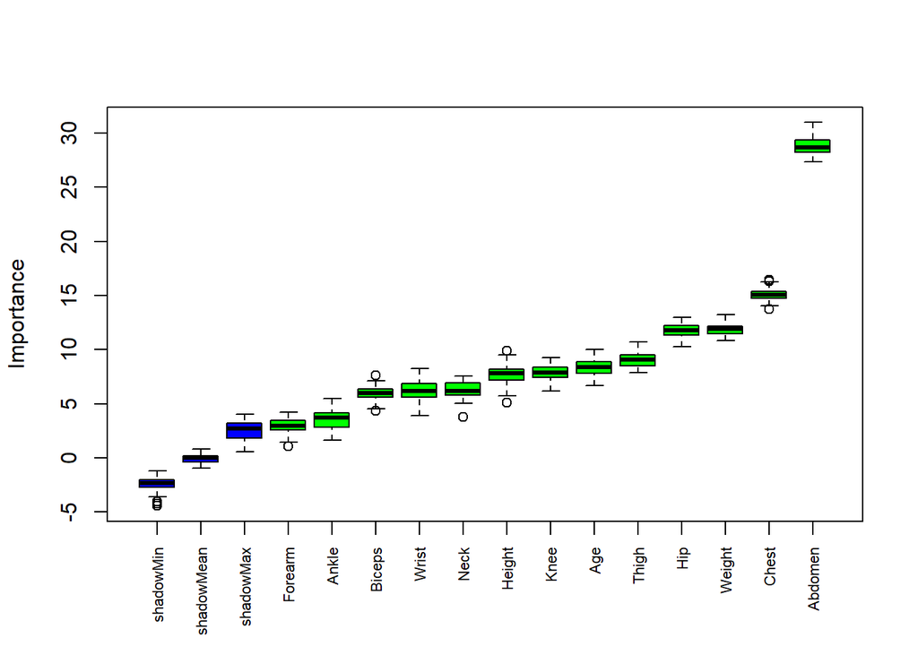

#### Correlação

[output not shown]

[output cut: 126 more lines]

[output not shown]

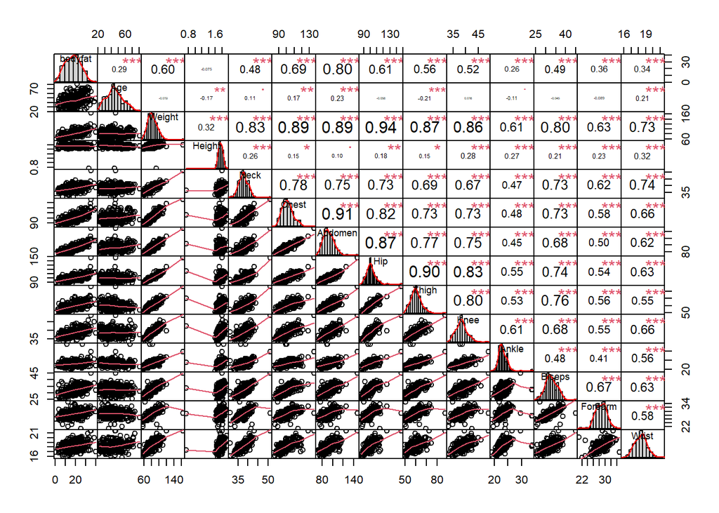

```r
chart.Correlation((Bodyfat), histogram = TRUE)
```

```r
Bodyfat <- Bodyfat %>%
  select(-Chest,-Hip,-Weight,-Thigh,-Knee,-Neck)

Bodyfat
```

```
## # A tibble: 250 × 8
##    bodyfat   Age Height Abdomen Ankle Biceps Forearm Wrist
##      <dbl> <dbl>  <dbl>   <dbl> <dbl>  <dbl>   <dbl> <dbl>
##  1    12.3    23   1.69    85.2  21.9   32      27.4  17.1
##  2     6.1    22   1.81    83    23.4   30.5    28.9  18.2
##  3    25.3    22   1.66    87.9  24     28.8    25.2  16.6
##  4    10.4    26   1.81    86.4  22.8   32.4    29.4  18.2
##  5    28.7    24   1.78   100    24     32.2    27.7  17.7
##  6    20.9    24   1.87    94.4  25.6   35.7    30.6  18.8
##  7    19.2    26   1.74    90.7  22.9   31.9    27.8  17.7
##  8    12.4    25   1.81    88.5  23.2   30.5    29    18.8
##  9     4.1    25   1.85    82.5  23.8   35.9    31.1  18.2
## 10    11.7    23   1.84    88.6  25     35.6    30    19.2
## # … with 240 more rows
```

###3 - Modelo, escolhendo o melhor modelo.

```r
reg_gordura_full <- lm(bodyfat ~.,data=Bodyfat)
summary(reg_gordura_full)
```

```
##
## Call:
## lm(formula = bodyfat ~ ., data = Bodyfat)
##
## Residuals:
##      Min       1Q   Median       3Q      Max
## -14.8866  -2.9850  -0.1981   3.4318  10.0912
##
## Coefficients:
##             Estimate Std. Error t value Pr(>|t|)
## (Intercept) -3.64671    6.99333  -0.521 0.602527
## Age          0.09234    0.02620   3.524 0.000508 ***
## Height      -6.79802    3.37369  -2.015 0.045010 *
## Abdomen      0.69297    0.04084  16.967  < 2e-16 ***
## Ankle        0.03303    0.21303   0.155 0.876929
## Biceps       0.02626    0.15702   0.167 0.867336
## Forearm      0.37179    0.19901   1.868 0.062944 .
## Wrist       -2.51425    0.49553  -5.074 7.77e-07 ***
## ---
## Signif. codes:  0 '***' 0.001 '**' 0.01 '*' 0.05 '.' 0.1 ' ' 1
##
## Residual standard error: 4.414 on 242 degrees of freedom
## Multiple R-squared:  0.7126, Adjusted R-squared:  0.7043
## F-statistic: 85.71 on 7 and 242 DF,  p-value: < 2.2e-16
```

Analisando o teste F, percebemos que existem variáveis significativas no conjunto de variáveis, mas no teste t, somente 4 estavam estatisticamente diferentes de 0.

#### Executar seleção de variáveis

regressao por forward com a regra de AIC para o forward precisa primeiro ter o modelo sem nenhuma variavel ou seja, apenas o modelo media (b0)

```r
reg_gordura_nula <- lm(bodyfat ~ 1, data=Bodyfat)
summary(reg_gordura_nula)
```

```
##
## Call:
## lm(formula = bodyfat ~ 1, data = Bodyfat)
##
## Residuals:
##     Min      1Q  Median      3Q     Max
## -18.414  -6.614   0.086   6.161  20.986
##
## Coefficients:
##             Estimate Std. Error t value Pr(>|t|)
## (Intercept)  19.1140     0.5134   37.23   <2e-16 ***
## ---
## Signif. codes:  0 '***' 0.001 '**' 0.01 '*' 0.05 '.' 0.1 ' ' 1
##
## Residual standard error: 8.118 on 249 degrees of freedom
```

```r
# com ele podemos pedir o step saindo dele, ate aquele modelo com todas as vars
forw <- step(reg_gordura_nula, scope=list(lower=reg_gordura_nula, upper=reg_gordura_full), direction = "forward")
```

```
## Start:  AIC=1048.02
## bodyfat ~ 1
##
##           Df Sum of Sq     RSS     AIC
## + Abdomen  1   10581.0  5827.2  791.21
## + Biceps   1    3906.5 12501.7  982.04
## + Forearm  1    2068.0 14340.2 1016.34
## + Wrist    1    1909.0 14499.2 1019.10
## + Age      1    1393.9 15014.3 1027.82
## + Ankle    1    1080.5 15327.7 1032.99
## <none>                 16408.2 1048.02
## + Height   1      92.7 16315.5 1048.60
##
## Step:  AIC=791.21
## bodyfat ~ Abdomen
##
##           Df Sum of Sq    RSS    AIC
## + Wrist    1    666.56 5160.7 762.84
## + Height   1    419.08 5408.2 774.55
## + Ankle    1    222.08 5605.2 783.50
## + Age      1    204.66 5622.6 784.27
## + Biceps   1    115.67 5711.6 788.20
## + Forearm  1     47.31 5779.9 791.17
## <none>                 5827.2 791.21
##
## Step:  AIC=762.84
## bodyfat ~ Abdomen + Wrist
##
##           Df Sum of Sq    RSS    AIC
## + Age      1   281.086 4879.6 750.84
## + Height   1   159.406 5001.3 757.00
## <none>                 5160.7 762.84
## + Ankle    1    24.362 5136.3 763.66
## + Forearm  1    13.242 5147.4 764.20
## + Biceps   1     2.816 5157.9 764.70
##
## Step:  AIC=750.84
## bodyfat ~ Abdomen + Wrist + Age
##
##           Df Sum of Sq    RSS    AIC
## + Forearm  1    83.887 4795.7 748.50
## + Height   1    76.882 4802.7 748.87
## <none>                 4879.6 750.84
## + Biceps   1    18.184 4861.4 751.91
## + Ankle    1     0.049 4879.6 752.84
##
## Step:  AIC=748.5
## bodyfat ~ Abdomen + Wrist + Age + Forearm
##
##          Df Sum of Sq    RSS    AIC
## + Height  1    78.696 4717.0 746.37
## <none>                4795.7 748.50
## + Biceps  1     0.609 4795.1 750.47
## + Ankle   1     0.033 4795.7 750.50
##
## Step:  AIC=746.37
## bodyfat ~ Abdomen + Wrist + Age + Forearm + Height
##
##          Df Sum of Sq    RSS    AIC
## <none>                4717.0 746.37
## + Biceps  1   0.59086 4716.4 748.34
## + Ankle   1   0.51428 4716.5 748.34
```

```r
summary(forw)
```

```
##
## Call:
## lm(formula = bodyfat ~ Abdomen + Wrist + Age + Forearm + Height,
##     data = Bodyfat)
##
## Residuals:
##      Min       1Q   Median       3Q      Max
## -14.7252  -2.9679  -0.2334   3.4249  10.0531
##
## Coefficients:
##             Estimate Std. Error t value Pr(>|t|)
## (Intercept) -3.59632    6.87803  -0.523 0.601538
## Abdomen      0.69728    0.03537  19.713  < 2e-16 ***
## Wrist       -2.46886    0.44980  -5.489 1.01e-07 ***
## Age          0.09027    0.02453   3.681 0.000286 ***
## Forearm      0.38478    0.18275   2.105 0.036271 *
## Height      -6.76730    3.35412  -2.018 0.044727 *
## ---
## Signif. codes:  0 '***' 0.001 '**' 0.01 '*' 0.05 '.' 0.1 ' ' 1
##
## Residual standard error: 4.397 on 244 degrees of freedom
## Multiple R-squared:  0.7125, Adjusted R-squared:  0.7066
## F-statistic:   121 on 5 and 244 DF,  p-value: < 2.2e-16
```

regressao por backward com a regra de AIC

```r
backw <-  step(reg_gordura_full, direction = "backward")
```

```
## Start:  AIC=750.31
## bodyfat ~ Age + Height + Abdomen + Ankle + Biceps + Forearm +
##     Wrist
##
##           Df Sum of Sq     RSS    AIC
## - Ankle    1       0.5  4716.4 748.34
## - Biceps   1       0.5  4716.5 748.34
## <none>                  4716.0 750.31
## - Forearm  1      68.0  4784.0 751.89
## - Height   1      79.1  4795.1 752.47
## - Age      1     242.0  4958.0 760.82
## - Wrist    1     501.7  5217.7 773.59
## - Abdomen  1    5610.2 10326.1 944.24
##
## Step:  AIC=748.34
## bodyfat ~ Age + Height + Abdomen + Biceps + Forearm + Wrist
##
##           Df Sum of Sq     RSS    AIC
## - Biceps   1       0.6  4717.0 746.37
## <none>                  4716.4 748.34
## - Forearm  1      67.9  4784.3 749.91
## - Height   1      78.7  4795.1 750.47
## - Age      1     253.4  4969.8 759.42
## - Wrist    1     560.8  5277.2 774.42
## - Abdomen  1    5763.9 10480.4 945.95
##
## Step:  AIC=746.37
## bodyfat ~ Age + Height + Abdomen + Forearm + Wrist
##
##           Df Sum of Sq     RSS    AIC
## <none>                  4717.0 746.37
## - Height   1      78.7  4795.7 748.50
## - Forearm  1      85.7  4802.7 748.87
## - Age      1     261.9  4978.9 757.88
## - Wrist    1     582.4  5299.4 773.47
## - Abdomen  1    7512.8 12229.8 982.54
```

```r
summary(backw)
```

```
##
## Call:
## lm(formula = bodyfat ~ Age + Height + Abdomen + Forearm + Wrist,
##     data = Bodyfat)
##
## Residuals:
##      Min       1Q   Median       3Q      Max
## -14.7252  -2.9679  -0.2334   3.4249  10.0531
##
## Coefficients:
##             Estimate Std. Error t value Pr(>|t|)
## (Intercept) -3.59632    6.87803  -0.523 0.601538
## Age          0.09027    0.02453   3.681 0.000286 ***
## Height      -6.76730    3.35412  -2.018 0.044727 *
## Abdomen      0.69728    0.03537  19.713  < 2e-16 ***
## Forearm      0.38478    0.18275   2.105 0.036271 *
## Wrist       -2.46886    0.44980  -5.489 1.01e-07 ***
## ---
## Signif. codes:  0 '***' 0.001 '**' 0.01 '*' 0.05 '.' 0.1 ' ' 1
##
## Residual standard error: 4.397 on 244 degrees of freedom
## Multiple R-squared:  0.7125, Adjusted R-squared:  0.7066
## F-statistic:   121 on 5 and 244 DF,  p-value: < 2.2e-16
```

regressao por stepwise com a regra de AIC

```r
stepw <- step(reg_gordura_full, direction = "both")
```

```
## Start:  AIC=750.31
## bodyfat ~ Age + Height + Abdomen + Ankle + Biceps + Forearm +
##     Wrist
##
##           Df Sum of Sq     RSS    AIC
## - Ankle    1       0.5  4716.4 748.34
## - Biceps   1       0.5  4716.5 748.34
## <none>                  4716.0 750.31
## - Forearm  1      68.0  4784.0 751.89
## - Height   1      79.1  4795.1 752.47
## - Age      1     242.0  4958.0 760.82
## - Wrist    1     501.7  5217.7 773.59
## - Abdomen  1    5610.2 10326.1 944.24
##
## Step:  AIC=748.34
## bodyfat ~ Age + Height + Abdomen + Biceps + Forearm + Wrist
##
##           Df Sum of Sq     RSS    AIC
## - Biceps   1       0.6  4717.0 746.37
## <none>                  4716.4 748.34
## - Forearm  1      67.9  4784.3 749.91
## + Ankle    1       0.5  4716.0 750.31
## - Height   1      78.7  4795.1 750.47
## - Age      1     253.4  4969.8 759.42
## - Wrist    1     560.8  5277.2 774.42
## - Abdomen  1    5763.9 10480.4 945.95
##
## Step:  AIC=746.37
## bodyfat ~ Age + Height + Abdomen + Forearm + Wrist
##
##           Df Sum of Sq     RSS    AIC
## <none>                  4717.0 746.37
## + Biceps   1       0.6  4716.4 748.34
## + Ankle    1       0.5  4716.5 748.34
## - Height   1      78.7  4795.7 748.50
## - Forearm  1      85.7  4802.7 748.87
## - Age      1     261.9  4978.9 757.88
## - Wrist    1     582.4  5299.4 773.47
## - Abdomen  1    7512.8 12229.8 982.54
```

```r
summary(stepw)
```

```
##
## Call:
## lm(formula = bodyfat ~ Age + Height + Abdomen + Forearm + Wrist,
##     data = Bodyfat)
##
## Residuals:
##      Min       1Q   Median       3Q      Max
## -14.7252  -2.9679  -0.2334   3.4249  10.0531
##
## Coefficients:
##             Estimate Std. Error t value Pr(>|t|)
## (Intercept) -3.59632    6.87803  -0.523 0.601538
## Age          0.09027    0.02453   3.681 0.000286 ***
## Height      -6.76730    3.35412  -2.018 0.044727 *
## Abdomen      0.69728    0.03537  19.713  < 2e-16 ***
## Forearm      0.38478    0.18275   2.105 0.036271 *
## Wrist       -2.46886    0.44980  -5.489 1.01e-07 ***
## ---
## Signif. codes:  0 '***' 0.001 '**' 0.01 '*' 0.05 '.' 0.1 ' ' 1
##
## Residual standard error: 4.397 on 244 degrees of freedom
## Multiple R-squared:  0.7125, Adjusted R-squared:  0.7066
## F-statistic:   121 on 5 and 244 DF,  p-value: < 2.2e-16
```

Deixa somente as variáveis abaixo: Age + Height + Abdomen + Forearm + Wrist

```r
Bodyfat <- Bodyfat %>%
  select(-Ankle,-Biceps)

Bodyfat
```

```
## # A tibble: 250 × 6
##    bodyfat   Age Height Abdomen Forearm Wrist
##      <dbl> <dbl>  <dbl>   <dbl>   <dbl> <dbl>
##  1    12.3    23   1.69    85.2    27.4  17.1
##  2     6.1    22   1.81    83      28.9  18.2
##  3    25.3    22   1.66    87.9    25.2  16.6
##  4    10.4    26   1.81    86.4    29.4  18.2
##  5    28.7    24   1.78   100      27.7  17.7
##  6    20.9    24   1.87    94.4    30.6  18.8
##  7    19.2    26   1.74    90.7    27.8  17.7
##  8    12.4    25   1.81    88.5    29    18.8
##  9     4.1    25   1.85    82.5    31.1  18.2
## 10    11.7    23   1.84    88.6    30    19.2
## # … with 240 more rows
```

8. Análise de Resíduo############################### 8a. Plotando o gráfico de Residuo x Ajustado######## ajustado X resíduo

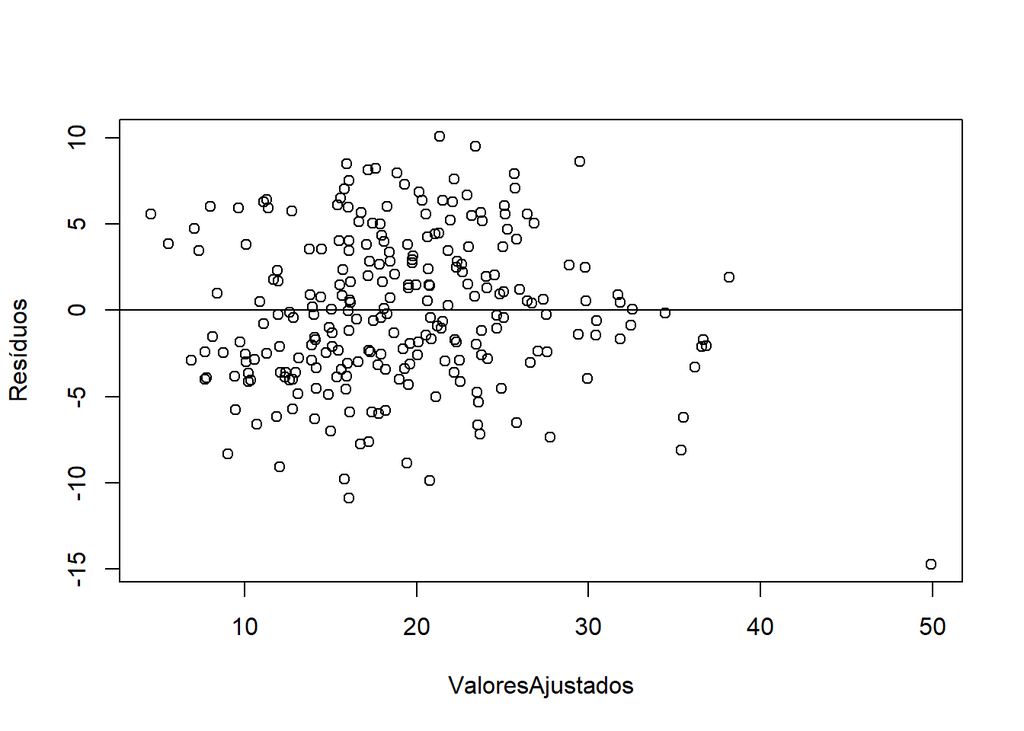

```r
plot(fitted(stepw),residuals(stepw),xlab="ValoresAjustados",ylab="Resíduos")
abline(h=0)
```

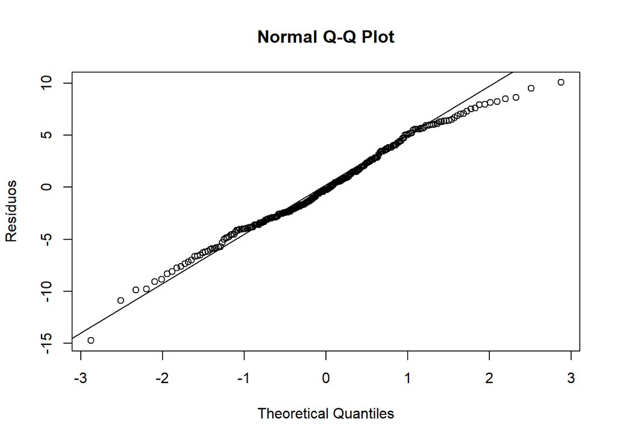

```r
# qqplot
qqnorm(residuals(stepw), ylab="Resíduos")
qqline(residuals(stepw))
```

#8b. Fazendo Teste de normalidade de Shapiro############ # teste de normalidade # h0: os dados sao normais # h1: os dados nao sao normais

```r
mean(stepw$residuals)
```

```
## [1] 7.840256e-17
```

```r
shapiro.test(stepw$residuals)
```

```
##
##  Shapiro-Wilk normality test
##
## data:  stepw$residuals
## W = 0.99087, p-value = 0.1202
```

# visualizando o histograma

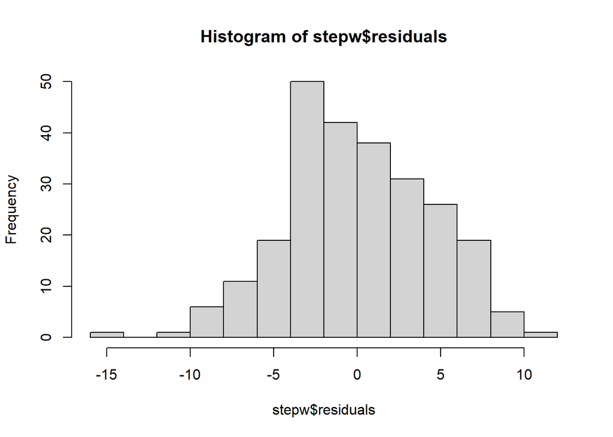

```r
hist(stepw$residuals)
```

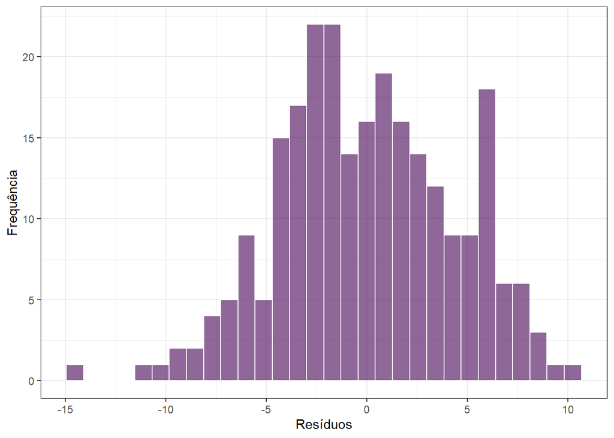

```r
# fazendo o histograma de uma forma mais bonita
Bodyfat %>%
  mutate(residuos = stepw$residuals) %>%
  ggplot(aes(x = residuos)) +
  geom_histogram(color = "white",
                 fill = "#440154FF",
                 bins = 30,
                 alpha = 0.6) +
  labs(x = "Resíduos",
       y = "Frequência") +
  theme_bw()
```

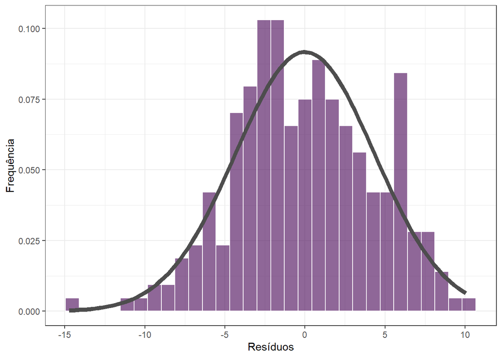

```r
# adicionando uma curva da normal por cima
Bodyfat %>%
  mutate(residuos = stepw$residuals) %>%
  ggplot(aes(x = residuos)) +
  geom_histogram(aes(y = ..density..),
                 color = "white",
                 fill = "#440154FF",
                 bins = 30,
                 alpha = 0.6) +
  stat_function(fun = dnorm,
                args = list(mean = mean(stepw$residuals),
                            sd = sd(stepw$residuals)),
                size = 2, color = "grey30") +
  scale_color_manual(values = "grey50") +
  labs(x = "Resíduos",
       y = "Frequência") +
  theme_bw()
```

8c. Fazendo o Teste de homogeneidade de variância############ teste de homogeneidade de variancia Breusch-Pagan test h0: as variâncias dos erros sao iguais (homoscedasticidade) h1: as variâncias dos erros nao sao iguais (heteroscedasticidade)

```r
bptest(stepw) #library lmtest
```

```
##
##  studentized Breusch-Pagan test
##
## data:  stepw
## BP = 7.6315, df = 5, p-value = 0.1777
```

VIF

```r
# verificando VIF
ols_vif_tol(stepw)
```

```
##   Variables Tolerance      VIF
## 1       Age 0.8075479 1.238317
## 2    Height 0.8269324 1.209289
## 3   Abdomen 0.5563129 1.797549
## 4   Forearm 0.5741634 1.741665
## 5     Wrist 0.4429118 2.257786
```

Analizando o Modelo

```r
bodyfat_sw_model <- lm(bodyfat ~., data=Bodyfat)
summary(bodyfat_sw_model)
```

```
##
## Call:
## lm(formula = bodyfat ~ ., data = Bodyfat)
##
## Residuals:
##      Min       1Q   Median       3Q      Max
## -14.7252  -2.9679  -0.2334   3.4249  10.0531
##
## Coefficients:
##             Estimate Std. Error t value Pr(>|t|)
## (Intercept) -3.59632    6.87803  -0.523 0.601538
## Age          0.09027    0.02453   3.681 0.000286 ***
## Height      -6.76730    3.35412  -2.018 0.044727 *
## Abdomen      0.69728    0.03537  19.713  < 2e-16 ***
## Forearm      0.38478    0.18275   2.105 0.036271 *
## Wrist       -2.46886    0.44980  -5.489 1.01e-07 ***
## ---
## Signif. codes:  0 '***' 0.001 '**' 0.01 '*' 0.05 '.' 0.1 ' ' 1
##
## Residual standard error: 4.397 on 244 degrees of freedom
## Multiple R-squared:  0.7125, Adjusted R-squared:  0.7066
## F-statistic:   121 on 5 and 244 DF,  p-value: < 2.2e-16
```

```r
predict_sw<- predict(bodyfat_sw_model, newdata = Bodyfat)

rmse(Bodyfat, truth = bodyfat, estimate = predict_sw)
```

```
## # A tibble: 1 × 3
##   .metric .estimator .estimate
##   <chr>   <chr>          <dbl>
## 1 rmse    standard        4.34
```

Verificando o RMSE

```r
rmse_na_mao<-sqrt(mean(bodyfat_sw_model$residuals^2))
rmse_na_mao
```

```
## [1] 4.343739
```

MAE

```r
mae(Bodyfat, truth = bodyfat, estimate = predict_sw)
```

```
## # A tibble: 1 × 3
##   .metric .estimator .estimate
##   <chr>   <chr>          <dbl>
## 1 mae     standard        3.55
```